solutions

# Rasters

# Overview

This notebook will demonstrate how to download Cal-Adapt data as rasters.

# Setup

Load caladaptR and the other package we’re going to need. (If you haven’t installed these yet, see this [setup script](https://github.com/ucanr-igis/caladaptr-res/blob/main/docs/workshops/ca_intro_apr22/scripts/caladaptr_setup.R)).

```r
library(caladaptr)
library(units)
library(dplyr)
library(lubridate)
library(sf)
library(stars)
library(conflicted)
conflict_prefer("filter", "dplyr", quiet = TRUE)
conflict_prefer("count", "dplyr", quiet = TRUE)
conflict_prefer("select", "dplyr", quiet = TRUE)
```

# Downloading Rasters

The same API Request object can be used to get raster data if you feed it into `ca_getrst_stars()`.

For additional info on downloading and analyzing rasters, see the 3 articles on [Downloading Rasters](https://ucanr-igis.github.io/caladaptr/articles/rasters-pt1.html).

```r
sierra_cap <- ca_loc_aoipreset(type = "climregions", idfld = "name", idval = "Sierra") %>%
  ca_livneh(TRUE) %>%
  ca_period("year") %>%
  ca_cvar("pr") %>%
  ca_years(start = 1970, end = 2010)

sierra_cap
```

```
Cal-Adapt API Request
Location(s):
  AOI Preset: climregions
  name(s): Sierra
Variable(s): pr
Temporal aggregration period(s): year
Livneh data: TRUE
Dates: 1970-01-01 to 2010-12-31
```

```r
sierra_cap %>% ca_preflight(check_for = "getrst")
```

```
General issues
 - none found
Issues for downloading rasters
 - none found
```

```r
plot(sierra_cap, locagrid = TRUE)
```

[interactive chart not shown]

To fetch the data as TIFs, use :

```r
tiff_dir <- "./data"

sierra_tiff_fn <- sierra_cap %>%
  ca_getrst_stars(out_dir = tiff_dir, mask = TRUE, quiet = TRUE, overwrite = FALSE)
```

**Pro Tip:**

- to avoid downloading the same TIF multiple times, use the same output directory and set `overwrite = FALSE`

`ca_getrst_stars()` returns a vector of TIF files that were downloaded. To work with them, you next have to load them back into R as stars objects (space-time arrays) using `ca_stars_read()`:

```r
sierra_stars_lst <- ca_stars_read(sierra_tiff_fn)
length(sierra_stars_lst)
```

```
[1] 1
```

```r
sierra_stars_lst[[1]]
```

```
stars object with 3 dimensions and 1 attribute
attribute(s):
                                 Min.  1st Qu.   Median     Mean  3rd Qu.     Max.   NA's
pr_year_livneh_name-Sierra  0.2009817 2.037323 2.821092 3.106411 3.863086 12.43626 123615
dimension(s):
     from to   offset   delta refsys point values x/y
x       1 58 -121.688  0.0625 WGS 84 FALSE   NULL [x]
y       1 71   40.125 -0.0625 WGS 84 FALSE   NULL [y]
year    1 41     1970       1     NA    NA   NULL
```

# Plot

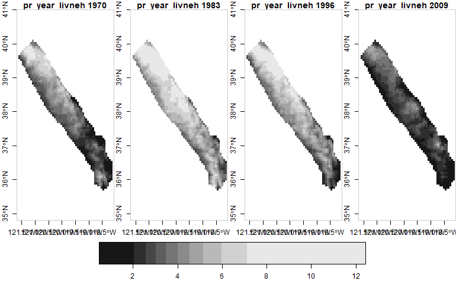

```r
plot(sierra_stars_lst[[1]] %>% slice(index = seq(1,40,length.out =4), along = "year"),
     axes = TRUE,
     main = attributes(sierra_stars_lst[[1]])$ca_metadata$slug)
```

Not sure what the units are? You can double-check by viewing the metadata for the slug from the catalog:

```r
ca_catalog_search("pr_year_livneh")
```

```
pr_year_livneh
  name: Livneh yearly average precipitation historical
  url: https://api.cal-adapt.org/api/series/pr_year_livneh/
  tres: annual
  begin: 1950-01-01T00:00:00Z
  end: 2013-12-31T00:00:00Z
  units: mm
  num_rast: 64
  id: 382
  xmin: -124.5625
  xmax: -113.375
  ymin: 31.5625
  ymax: 43.75
```

# Subset by Dimension

Subsetting stars objects by a dimension is the counterpart to doing an attribute query in GIS. You can use dplyr filter function as you would a tibble. For example, to get the precipitation for only the 1990s:

```r
sierra_stars_lst[[1]] %>% filter(year >= 1990, year < 2000)
```

```
stars object with 3 dimensions and 1 attribute
attribute(s):
                                 Min.  1st Qu.   Median    Mean  3rd Qu.     Max.  NA's
pr_year_livneh_name-Sierra  0.4325525 2.126165 2.905097 3.25017 4.015097 11.33755 30150
dimension(s):
```

|  | from | to | offset | delta | refsys | point | values | x/y |
| --- | --- | --- | --- | --- | --- | --- | --- | --- |
| x | 1 | 58 | -121.688 | 0.0625 | WGS 84 | FALSE | NULL | [x] |
| y | 1 | 71 | 40.125 | -0.0625 | WGS 84 | FALSE | NULL | [y] |
| year | 1 | 10 | 1990 | 1 | NA | NA | NULL |  |

To get the values of a dimension, you can use

```r
(x_range <- sierra_stars_lst[[1]] %>% st_get_dimension_values("x"))
```

```
 [1] -121.6562 -121.5938 -121.5312 -121.4688 -121.4062 -121.3438 -121.2812 -121.2188 -121.1562 -121.0938 -121.0312
[12] -120.9688 -120.9062 -120.8438 -120.7812 -120.7188 -120.6562 -120.5938 -120.5312 -120.4688 -120.4062 -120.3438
[23] -120.2812 -120.2188 -120.1562 -120.0938 -120.0312 -119.9688 -119.9062 -119.8438 -119.7812 -119.7188 -119.6562
[34] -119.5938 -119.5312 -119.4688 -119.4062 -119.3438 -119.2812 -119.2188 -119.1562 -119.0938 -119.0312 -118.9688
[45] -118.9062 -118.8438 -118.7812 -118.7188 -118.6562 -118.5938 -118.5312 -118.4688 -118.4062 -118.3438 -118.2812
[56] -118.2188 -118.1562 -118.0938
```

```r
(yr_range <- sierra_stars_lst[[1]] %>% st_get_dimension_values("year"))
```

```
 [1] 1970 1971 1972 1973 1974 1975 1976 1977 1978 1979 1980 1981 1982 1983 1984 1985 1986 1987 1988 1989 1990 1991
[23] 1992 1993 1994 1995 1996 1997 1998 1999 2000 2001 2002 2003 2004 2005 2006 2007 2008 2009 2010
```

You can also use square bracket notation as you would an array. Just put an extra comma at the beginning of the bracket.

```r
sierra_stars_lst[[1]][ , , , which(yr_range >= 1990 & yr_range < 2000)]
```

```
stars object with 3 dimensions and 1 attribute
attribute(s):
                                 Min.  1st Qu.   Median    Mean  3rd Qu.     Max.  NA's
pr_year_livneh_name-Sierra  0.4325525 2.126165 2.905097 3.25017 4.015097 11.33755 30150
dimension(s):
```

|  | from | to | offset | delta | refsys | point | values | x/y |
| --- | --- | --- | --- | --- | --- | --- | --- | --- |
| x | 1 | 58 | -121.688 | 0.0625 | WGS 84 | FALSE | NULL | [x] |
| y | 1 | 71 | 40.125 | -0.0625 | WGS 84 | FALSE | NULL | [y] |
| year | 21 | 30 | 1970 | 1 | NA | NA | NULL |  |

# Spatial Selection

To spatially select, you can put a SF object in the first slot of the square bracket notation. Let’s get the precipitation history for Yosemite NP:

```r
(ynp_bnd_sf <- st_read("https://raw.githubusercontent.com/ucanr-igis/caladaptr-res/main/geoms/ynp_bnd.geojson"))
```

```
  UNIT_CODE                                                                           GIS_NOTES
1      YOSE Lands - http://landsnet.nps.gov/tractsnet/documents/YOSE/METADATA/yose_metadata.xml
               UNIT_NAME  DATE_EDIT STATE REGION GNIS_ID     UNIT_TYPE CREATED_BY
1 Yosemite National Park 2016-01-27    CA     PW  255923 National Park      Lands
                                                METADATA PARKNAME                       geometry
1 http://nrdata.nps.gov/programs/Lands/YOSE_METADATA.xml Yosemite POLYGON ((-119.8456 37.8327...
```

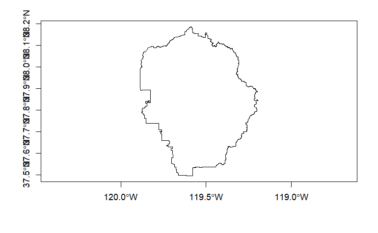

```r
plot(ynp_bnd_sf$geometry, axes = TRUE)
```

To do a spatial selection, put the sf object in the first slot in the square brackets:

```r
ynp_pr_stars <- sierra_stars_lst[[1]][ynp_bnd_sf , , , ]
ynp_pr_stars
```

```
stars object with 3 dimensions and 1 attribute
attribute(s):
                                 Min. 1st Qu.  Median    Mean  3rd Qu.     Max. NA's
pr_year_livneh_name-Sierra  0.9827738 2.46228 3.08287 3.32722 3.922521 8.374605 2747
dimension(s):
```

|  | from | to | offset | delta | refsys | point | values | x/y |
| --- | --- | --- | --- | --- | --- | --- | --- | --- |
| x | 29 | 40 | -121.688 | 0.0625 | WGS 84 | FALSE | NULL | [x] |
| y | 32 | 43 | 40.125 | -0.0625 | WGS 84 | FALSE | NULL | [y] |
| year | 1 | 41 | 1970 | 1 | NA | NA | NULL |  |

Plot to verify:

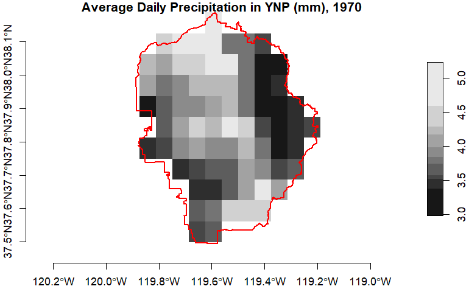

```r
{plot(ynp_pr_stars %>% slice(index = 1, along = "year"),
     axes = TRUE, main = "Average Daily Precipitation in YNP (mm), 1970", reset = FALSE)
plot(ynp_bnd_sf$geometry, border = "red", lwd = 2, add = TRUE)}
```

# Convert Values / Raster Algebra

Math operators (like `* / - +`) do ‘pixelwise’ operations on stars objects, just like regular arrays.

To compute the yearly summary in inches, rather than daily average in mm, we just multiply the stars object by a conversion constant. A mm is 0.0393701 inches, so to go from daily averages in mm to annual total in inches:

```r
(ynp_prtotal_stars <- ynp_pr_stars * 0.0393701 * 365)
```

```
stars object with 3 dimensions and 1 attribute
attribute(s):
                                Min.  1st Qu.   Median     Mean  3rd Qu.     Max. NA's
pr_year_livneh_name-Sierra  14.12254 35.38317 44.30111 47.81244 56.36696 120.3438 2747
dimension(s):
```

|  | from | to | offset | delta | refsys | point | values | x/y |
| --- | --- | --- | --- | --- | --- | --- | --- | --- |
| x | 29 | 40 | -121.688 | 0.0625 | WGS 84 | FALSE | NULL | [x] |
| y | 32 | 43 | 40.125 | -0.0625 | WGS 84 | FALSE | NULL | [y] |
| year | 1 | 41 | 1970 | 1 | NA | NA | NULL |  |

Plot the first year to verify:

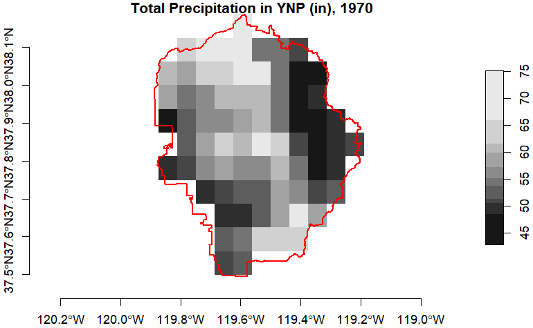

```r
{plot(ynp_prtotal_stars %>% slice(index = 1, along = "year"),
     axes = TRUE, main = "Total Precipitation in YNP (in), 1970", reset = FALSE)
plot(ynp_bnd_sf$geometry, border = "red", lwd = 2, add = TRUE)}
```

# Aggregate Across Time and Space

To take the average precip per pixel for the entire time range, use `st_apply()`. The `MARGIN` argument should be the indices of the dimensions you want to *keep*:

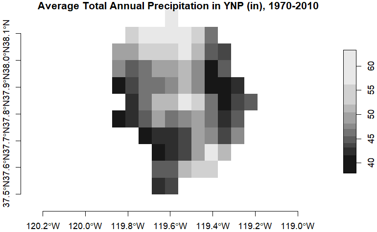

```r
ynp_prtotal_stars %>%
  st_apply(MARGIN = 1:2, FUN = mean) %>%
  plot(axes = TRUE, main = "Average Total Annual Precipitation in YNP (in), 1970-2010")
```

To take the average total precip of all pixels in the park per year, we simply change the value of `MARGIN` to 3 (because year is the third dimension). We also have to add `na.rm = TRUE` to tell the `mean` function to ignore all the NA values outside the park boundary:

```r
(ynp_pr_annual_avg_stars <- ynp_prtotal_stars %>%
  st_apply(MARGIN = 3, FUN = mean, na.rm = TRUE))
```

```
stars object with 1 dimensions and 1 attribute
attribute(s):
          Min.  1st Qu.  Median     Mean  3rd Qu.     Max.
mean  19.96104 37.36484 41.9291 47.81244 53.77562 90.80345
dimension(s):
```

|  | from | to | offset | delta | refsys | point | values |
| --- | --- | --- | --- | --- | --- | --- | --- |
| year | 1 | 41 | 1970 | 1 | NA | NA | NULL |

stars objects can be converted to data frames:

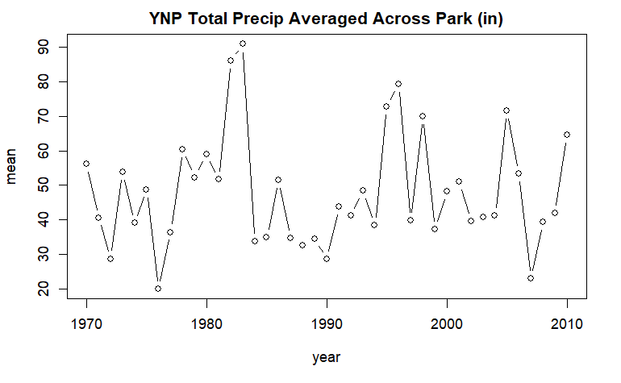

```r
ynp_pr_annual_avg_df <- ynp_pr_annual_avg_stars %>% as.data.frame
plot(ynp_pr_annual_avg_df, type="b", main = "YNP Total Precip Averaged Across Park (in)")
```

To plot the distribution of values, we can grab the individual values with `[]` (just like an array) and make a histogram:

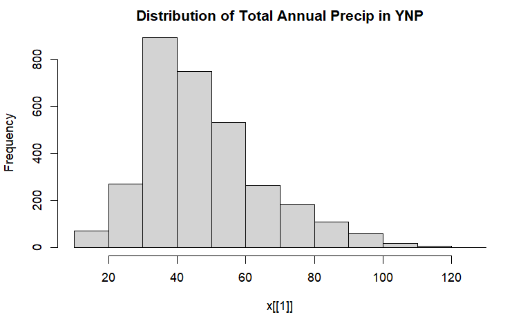

```r
hist(ynp_prtotal_stars, main = "Distribution of Total Annual Precip in YNP")
```

There is a **lot** more you can do with rasters, including pixel summaries, combining them into higher dimensional data cubes, spatially mosaicing them, etc. For more info, see the Rasters articles on the [website](https://ucanr-igis.github.io/caladaptr/).

#### Your Turn

Download historic precipitation data for the county where you live or work. [[Answer](https://bit.ly/3m7BcWM)]

```r
## Example: Mendocino County

ca_aoipreset_geom("counties", quiet = TRUE) %>%
  st_drop_geometry() %>%
  filter(name == "Mendocino") %>%
  select(name, state_name, fips)
```

```
       name state_name  fips
1 Mendocino California 06045
```

```r
mendocino_cap <- ca_loc_aoipreset(type = "counties", idfld = "fips", idval = "06045") %>%
  ca_livneh(TRUE) %>%
  ca_period("year") %>%
  ca_cvar("pr") %>%
  ca_years(start = 1970, end = 2010)

plot(mendocino_cap)
```

[interactive chart not shown]

```r
mendocino_fn <- mendocino_cap %>%
  ca_getrst_stars(out_dir = tempdir(), mask = TRUE, quiet = TRUE, overwrite = FALSE)

mendocino_stars_lst <- ca_stars_read(mendocino_fn)

mendocino_stars_lst[[1]]
```

```
stars object with 3 dimensions and 1 attribute
attribute(s):
                                Min.  1st Qu.   Median     Mean  3rd Qu.   Max. NA's
pr_year_livneh_fips-06045  0.9326811 2.792288 3.627976 3.892968 4.744806 11.229 7134
dimension(s):
     from to   offset   delta refsys point values x/y
x       1 20 -124.062  0.0625 WGS 84 FALSE   NULL [x]
y       1 21  40.0625 -0.0625 WGS 84 FALSE   NULL [y]
year    1 41     1970       1     NA    NA   NULL
```

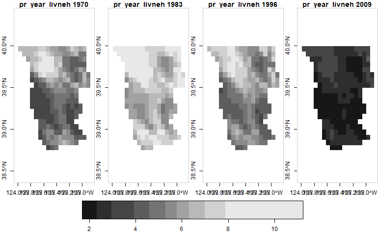

```r
plot(mendocino_stars_lst[[1]] %>% slice(index = seq(1,40,length.out =4), along = "year"),
     axes = TRUE,
     main = attributes(mendocino_stars_lst[[1]])$ca_metadata$slug)
```